# 02 - İş Yükü Analizi

## Amaç ve Kapsam

Bu notebook, tezin donanım tahsisi ve derin öğrenme (Deep Learning) modelleme süreçlerine yön veren temel dinamikleri ampirik biçimde ortaya koyan kapsamlı bir **iş yükü karakterizasyonunu (workload characterization)** temsil etmektedir. Sonraki bölümlerde (Notebook 04 ve 05) inşa edilecek olan Random Forest, XGBoost, LightGBM standart modelleri ile sıralı (sequential) belleğe sahip derin öğrenme (CNN, LSTM, Hibrit) modellerinin başarısı, tamamen burada deşifre edilen veri örüntülerine dayanmaktadır.

Bu analiz doğrudan veriden hareketle bir savunma çizgisi oluşturur; teorik yaklaşımlardan ziyade verinin bizzat talep ettiği ağaç tabanlı ve derin öğrenme tabanlı mimarilerin inşasına nesnel bir geçiş köprüsü kurar.

```python
# ── 0. Environment & Path Setup ──────────────────────────────────────────────
import sys
import warnings
from pathlib import Path

warnings.filterwarnings("ignore")

PROJECT_ROOT = Path().resolve().parents[1]
if str(PROJECT_ROOT) not in sys.path:
    sys.path.insert(0, str(PROJECT_ROOT))

print(f"[Setup] Project root : {PROJECT_ROOT}")
print(f"[Setup] Python path  : {sys.executable}")
```

```
[Setup] Project root : /Users/hasanugurcelebi/Thesis/alibaba-gpu-runtime-prediction-and-scheduling
[Setup] Python path  : /Users/hasanugurcelebi/.pyenv/versions/3.11.6/bin/python
```

> **Kurulum doğrulandı.** `src.*` modülleri Python yoluna eklenmiş, `configs/paths.yaml` üzerinden dizinler doğrulanmıştır.

```python
# ── 1. Imports ────────────────────────────────────────────────────────────────
import numpy as np
import pandas as pd
import matplotlib.pyplot as plt
import seaborn as sns

from src.analysis import (
    load_prepared_job_table,
    compute_basic_stats,
    compute_runtime_histogram,
    compute_arrival_rate_series,
    summarize_workload,
)

# Unified visualisation theme
sns.set_theme(style="whitegrid", palette="muted")
plt.rcParams.update({
    "figure.figsize": (12, 6),
    "axes.titlesize": 14,
    "axes.labelsize": 12,
    "font.family": "DejaVu Sans",
})

print("[Setup] All imports OK.")
```

```
[Setup] All imports OK.
```

> **Bağımlılıklar hazır.** NumPy, Pandas, Matplotlib, Seaborn ve tüm `src.analysis` modülleri başarıyla içe aktarılmıştır.

Veri ön işleme ve filtreleme adımlarının ardından elde edilen analiz veri seti **82.184 iş** ve **14 öznitelik** içermektedir. Bu özniteliklerin bir kısmı doğrudan ham kayıtlardan alınırken, analiz yapılabilmesi için bir kısmı sonradan türetilmiştir:

**Temel Özellikler:**

- `job_id`,
- `gpu_demand`,
- `user`,
- `gpu_type`,
- `num_inst`,
- `num_cpu`,
- `job_runtime` (Hedef Değişken)

**Zamansal Özellikler (Türetilmiş):** İş yükünün zamana bağlı dağılımını görebilmek için ham zaman damgasından (timestamp) türetilmiştir:

- `arrival_time`,
- `arrival_sec`,
- `hour_of_day`,
- `day_of_week`

**Sistem Yükü Özellikleri (Sweep-Line Algoritması):** İşin geldiği andaki küme doluluğu doğrudan CPU/GPU kullanımından ziyade geliş-gidiş loglarının Sweep-Line Algoritması ile taranarak hesaplanmıştır:

- `cluster_load_cpu`,
- `cluster_load_gpu`,
- `active_job_count`

```python
# ── 2. Load dataset ───────────────────────────────────────────────────────────
print("[Step 1] Loading and preparing job table...")
job_df = load_prepared_job_table(dataset="main", time_unit="s")

print(f"[Step 1] Jobs : {len(job_df):,}  |  Columns : {list(job_df.columns)}")
job_df.head(3)
```

```
[Step 1] Loading and preparing job table...
[Step 1] Jobs : 82,184  |  Columns : ['job_id', 'arrival_time', 'arrival_sec', 'job_runtime', 'gpu_demand', 'user', 'gpu_type', 'num_inst', 'num_cpu', 'hour_of_day', 'day_of_week', 'cluster_load_cpu', 'cluster_load_gpu', 'active_job_count']
```

|  | job_id | arrival_time | arrival_sec | job_runtime | gpu_demand | user | gpu_type | num_inst | num_cpu | hour_of_day | day_of_week | cluster_load_cpu | cluster_load_gpu | active_job_count |
| --- | --- | --- | --- | --- | --- | --- | --- | --- | --- | --- | --- | --- | --- | --- |
| 0 | 1 | 1970-01-01 00:00:03 | 0.0 | 15748.0 | 0 | d4d51aca8806 | T4 | 12.0 | 6.0 | 0 | 3 | 0.0 | 0 | 0 |
| 1 | 2 | 1970-01-01 00:00:05 | 2.0 | 84.0 | 1 | a8192d6b0ae9 | MISC | 1.0 | 6.0 | 0 | 3 | 6.0 | 0 | 1 |
| 2 | 3 | 1970-01-01 00:00:21 | 18.0 | 46.0 | 1 | c7152ce0fec1 | T4 | 1.0 | 18.0 | 0 | 3 | 18.0 | 2 | 3 |

> Veri ön işleme ve filtreleme adımlarının ardından elde edilen veri seti **82.184 iş** ve toplam **14 adet öznitelik** içermektedir.

> **Temel Özellikler:**
> - `job_id` — İş tanımlayıcısı
> - `arrival_time` — Ham geliş zaman damgası
> - `arrival_sec` — İz başlangıcına göre saniye cinsinden geliş zamanı
> - `job_runtime` — Gerçek çalışma süresi (hedef değişken)
> - `gpu_demand` — Talep edilen GPU sayısı
> - `user` — İş sahibi kullanıcı (kategorik)
> - `gpu_type` — Kullanılan GPU tipi (kategorik)
> - `num_inst` — Kullanılan instance sayısı
> - `num_cpu` — Talep edilen CPU sayısı

> **Zamansal Özellikler:**
> - `hour_of_day` — Günün saati (0–23)
> - `day_of_week` — Haftanın günü (0 = Pazartesi)

> **Sistem Türevli Özellikler (Sweep-line):**
> - `cluster_load_cpu` — İşin geldiği andaki arka plan CPU yükü
> - `cluster_load_gpu` — İşin geldiği andaki arka plan GPU yükü
> - `active_job_count` — İşin geldiği anda kümede aktif iş sayısı

```python
# ── 3. Scalar statistics ──────────────────────────────────────────────────────
stats = compute_basic_stats(job_df)

print("=" * 50)
print("  Workload Basic Statistics")
print("=" * 50)
for k, v in stats.items():
    print(f"  {k:<25}: {v:>12,.2f}")
print("=" * 50)

# One-row summary table (LaTeX-ready)
summary_df = summarize_workload(job_df)
display(summary_df)
```

```
==================================================
  Workload Basic Statistics
==================================================
  num_jobs                 :    82,184.00
  mean_runtime             :     5,223.02
  median_runtime           :       594.00
  p95_runtime              :    24,110.05
  p99_runtime              :    67,432.38
  mean_gpu_demand          :         0.52
  max_gpu_demand           :         8.00
  time_span_hours          :       183.86
==================================================
```

|  | num_jobs | mean_runtime_sec | median_runtime_sec | p95_runtime_sec | p99_runtime_sec | mean_gpu_demand | max_gpu_demand | time_span_hours |
| --- | --- | --- | --- | --- | --- | --- | --- | --- |
| 0 | 82184 | 5223.019408 | 594.0 | 24110.05 | 67432.38 | 0.521598 | 8 | 183.858056 |

> İş yükünün zaman ve kaynak açısından yüksek derecede heterojen (değişken) olduğu görülmektedir. Ortalama iş süresi yaklaşık **5.223 saniye (≈ 1.5 saat)** iken, medyan sürenin yalnızca **594 saniye (≈ 10 dakika)** olması, iş sürelerinin **ağır kuyruklu (heavy-tailed)** bir dağılıma sahip olduğunu göstermektedir.

> Bu durum, işlerin büyük çoğunluğunun kısa sürede tamamlandığını; ancak az sayıdaki çok uzun işin ortalama süreyi önemli ölçüde yukarı çektiğini ortaya koymaktadır. Üst yüzdelik dilimlerde (percentile), iş sürelerinin P95 seviyesinde **~6.7 saat (24.110 s)** ve P99 seviyesinde **~18.7 saat (67.432 s)** mertebesine çıkması, nadir fakat devasa boyutlardaki işlerin sistem davranışında belirleyici bir etkiye sahip olduğunu gösterir. Bu muazzam varyasyon (CV >> 1), geleneksel normal dağılım varsayımını tümüyle geçersiz kılarak modellemede gürbüz (robust) hata metriklerinin (örn. MAE, MdAE) kullanımını zorunlu tutmaktadır.

> GPU talebi açısından incelendiğinde, ortalama GPU isteği 0.52 düzeyinde seyretse de maksimum talebin aynı anda **8 GPU'ya** kadar çıkması, iş yükünde devasa bir parçalı kaynak (fragmentation) ihtiyacı bulunduğunu kanıtlamaktadır. Test edilen iz verisi (trace), 183.86 saatlik (~7.7 gün) kesintisiz bir zaman dilimine yayılmış **82.184 onaylanmış işi** kapsamaktadır.

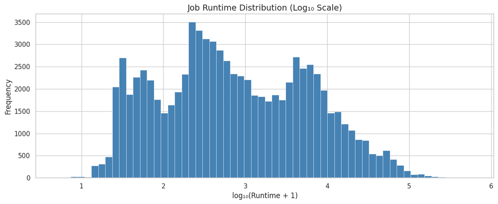

```python
# ── 4. Runtime histogram ──────────────────────────────────────────────────────
hist_counts, bin_edges = compute_runtime_histogram(job_df, bins=60, log_scale=True)
bin_centres = 0.5 * (bin_edges[:-1] + bin_edges[1:])

fig, ax = plt.subplots(figsize=(12, 5))
ax.bar(bin_centres, hist_counts, width=np.diff(bin_edges), color="steelblue",
       edgecolor="white", linewidth=0.4)
ax.set_xlabel("log₁₀(Runtime + 1)")
ax.set_ylabel("Frequency")
ax.set_title("Job Runtime Distribution (Log₁₀ Scale)")
plt.tight_layout()
plt.show()
```

> **Şekil 1 — Çalışma Süresi (Runtime) Dağılımı (Log₁₀ Ölçek):**

> En kritik bulgu; logaritmik dönüşüme (log transform) rağmen dağılımın sağ kuyruğunun log₁₀ ≈ 5 (~100,000 saniye) seviyelerine kadar uzanması ve simetrik bir çan eğrisi (normal dağılım) oluşturmamış olmasıdır. Bu asimetrik yapı, makine öğrenmesi modellerinin eğitiminde (Bölüm 04) ortalamaya dayalı hataları (MSE, RMSE) şiddetle saptıracaktır; dolayısıyla model performansını ölçerken uç değerlere (outliers) karşı dirençli olan **MAE (Ortalama Mutlak Hata)** ve özellikle **MdAE (Medyan Mutlak Hata)** gibi regresyon metriklerinin kullanılması teorik bir mecburiyettir.

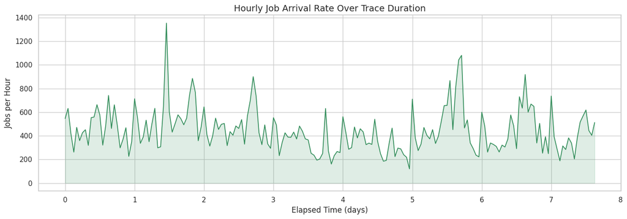

```python
# ── 5. Hourly arrival rate ────────────────────────────────────────────────────
# Note: uses lowercase "1h" alias — "1H" deprecated in pandas >= 2.2
arrival_series = compute_arrival_rate_series(job_df, freq="1h")

# Convert timedelta index to fractional days for readability
elapsed_days = arrival_series.index.total_seconds() / 86400

fig, ax = plt.subplots(figsize=(14, 5))
ax.plot(elapsed_days, arrival_series.values, lw=1.2, color="seagreen")
ax.fill_between(elapsed_days, arrival_series.values, alpha=0.15, color="seagreen")
ax.set_xlabel("Elapsed Time (days)")
ax.set_ylabel("Jobs per Hour")
ax.set_title("Hourly Job Arrival Rate Over Trace Duration")
plt.tight_layout()
plt.show()
```

> **Şekil 2 — Saatlik İş Geliş Hızı (Hourly Arrival Rate) (8 Günlük Kesit):**

> Zaman serisindeki bu şiddetli **sıçramalı (bursty)** yapı, anlık donanım darboğazlarının (hardware starvation) ana tetikleyicisidir. Sistemin bu dalgalanmalara göğüs gerebilmesi için, gelen statik iş yükünü pasif bir şekilde eriten basit FIFO'lardan öte, yaklaşan yük kümelerini öngörebilen proaktif ve makine öğrenmesi algılarına sahip çizelgeleme modellerine (SJF + Predictor) hayati ihtiyaç duyduğu açıkça görülmektedir. Zaman damgaları UTC (Coordinated Universal Time) Unix formatından türetilmiş olup analizler evrensel zaman uyumu üzerinden yapılmıştır.

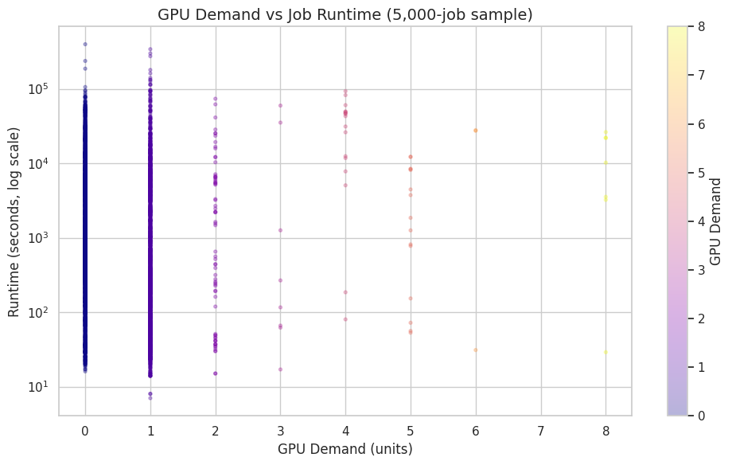

```python
# ── 6. GPU demand vs runtime scatter ─────────────────────────────────────────
sample = job_df.sample(min(5000, len(job_df)), random_state=42)

fig, ax = plt.subplots(figsize=(10, 6))
sc = ax.scatter(sample["gpu_demand"], sample["job_runtime"],
                alpha=0.3, s=8, c=sample["gpu_demand"], cmap="plasma")
plt.colorbar(sc, ax=ax, label="GPU Demand")
ax.set_yscale("log")
ax.set_xlabel("GPU Demand (units)")
ax.set_ylabel("Runtime (seconds, log scale)")
ax.set_title("GPU Demand vs Job Runtime (5,000-job sample)")
plt.tight_layout()
plt.show()
```

> **Şekil 3 — GPU Talebi vs. Çalışma Süresi (GPU Demand vs. Runtime Scatter - 5.000 İşlik Örneklem):**

> Bu görselin en güçlü ampirik mesajı şudur: **Sadece `gpu_demand` sütununa bakılarak bir işin ne kadar süreceği asla tahmin edilemez.** 1 GPU talep eden bir iş 10 saniye de sürebilmekte, 300.000 saniye de (yaklaşık 3.5 gün) de devam edebilmektedir. Bu muazzam belirsizlik; yapay zeka modellerine `user` (kullanıcı kodlama alışkanlıkları), `gpu_type` (donanım mimarisi) ve `hour_of_day` gibi bağlamsal/zamansal özniteliklerin (Feature Engineering - Bölüm 03) dahil edilmesinin neden sadece bir performans iyileştirmesi değil, mutlak bir mimari zorunluluk olduğunu görsel bağlamda kanıtlamaktadır.

## Özet

Bu notebook'ta gerçekleştirilen iş yükü karakterizasyon analizi, çizelgeleme optimizasyonunun gerekliliğini ve önerilen ML tabanlı yaklaşımın geçerliliğini doğrudan ampirik verilerle pekiştirmiştir:

[output not shown]

Bu bulgular, tezin SJF + ML tahmin entegrasyonuna dayalı mimari seçimini yalnızca teorik seviyede değil, tamamen veriye dayalı (data-driven) argümanlarla desteklemektedir.